# 5_clustering.R

dhicks1

Mon May 1 11:25:48 2017

This script applies affinity propagation clustering to the fitted word2vec model.

## Script setup

```r
library(tidyverse)
library(tidytext)
library(stringr)
library(apcluster)
library(wordVectors)

w2v_model_file = '4_glyphosate_w2v.bin'
load('3_comments_attachments.Rdata')
```

First let’s look at the distribution of negative/positive comments across commenter types

```r
comments %>%
    group_by(comment_id,
             commenter_type,
             valence) %>%
    summarize(comment_text = str_c(comment_text,
                                   collapse = ' ')) %>%
    ungroup() -> comments
type_by_valence = with(comments,
                       table(commenter_type, valence, useNA = 'ifany'))
type_by_valence
```

```
##               valence
## commenter_type neg pos <NA>
##     academic     3   1    0
##     advocacy    46   0    0
##     government   1   4    1
##     individual 252   7    4
##     industry     4  56    0
##     <NA>         0   2    0
```

```r
chisq.test(type_by_valence, simulate.p.value = TRUE)
```

```
##
##  Pearson's Chi-squared test with simulated p-value (based on 2000
##  replicates)
##
## data:  type_by_valence
## X-squared = 309.85, df = NA, p-value = 0.0004998
```

No surprise: strong correlation between advocacy/industry and neg/pos.

```r
## Load tokens
load('4_tokens_df.Rdata')
tokens_df %>%
    filter(commenter_type %in% c('advocacy', 'industry'),
           str_detect(token, '[a-z]+'),
           !str_detect(token, '[0-9]+')) -> tokens_df

tokens_df %>%
    .$token %>%
    unique %>%
    length
```

```
## [1] 12830
```

## Term selection: tf-idf

```r
token_counts_df = tokens_df %>%
    group_by(commenter_type, token) %>%
    summarize(token_n = n()) %>%
    bind_tf_idf(token, commenter_type, token_n) %>%
    ungroup()
token_counts_df
```

```
## # A tibble: 17,281 × 6
##    commenter_type                   token token_n           tf       idf
##             <chr>                   <chr>   <int>        <dbl>     <dbl>
## 1        advocacy __brain_cholinergic.pdf       1 9.752577e-06 0.6931472
## 2        advocacy                  _busse       2 1.950515e-05 0.6931472
## 3        advocacy                    _cdc       1 9.752577e-06 0.6931472
## 4        advocacy               _citation       2 1.950515e-05 0.6931472
## 5        advocacy                    _fda       1 9.752577e-06 0.6931472
## 6        advocacy                     _in       1 9.752577e-06 0.6931472
## 7        advocacy                 _letter       1 9.752577e-06 0.6931472
## 8        advocacy                    _nih       1 9.752577e-06 0.6931472
## 9        advocacy                   _text       2 1.950515e-05 0.6931472
## 10       advocacy                     _to       1 9.752577e-06 0.6931472
## # ... with 17,271 more rows, and 1 more variables: tf_idf <dbl>
```

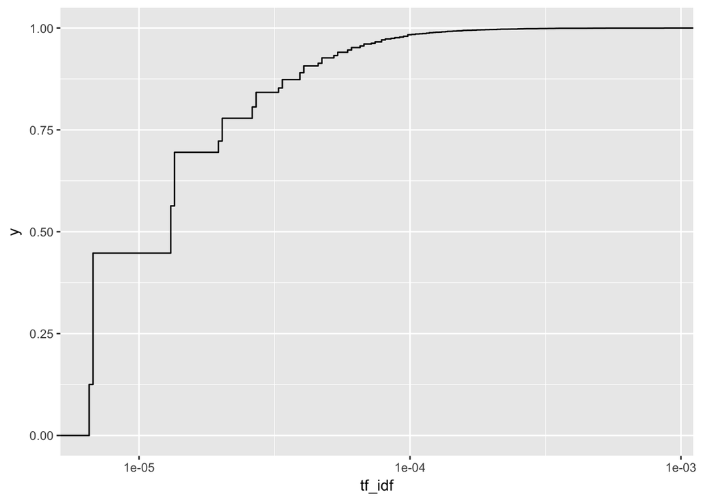

```r
ggplot(token_counts_df, aes(tf_idf)) +
    stat_ecdf() +
    scale_x_log10()
```

```r
token_counts_df %>%
    # filter(tf_idf >= quantile(tf_idf, probs = (.995))) %>%
    arrange(desc(tf_idf)) %>%
    head(60) %>%
    .$token %>%
    unique() %>%
    sort() %>%
    matrix(ncol = 2)
```

```
##       [,1]                   [,2]
##  [1,] "acquavella"           "medical"
##  [2,] "acquavella_et"        "moa"
##  [3,] "acquavella_et_al"     "nrdc"
##  [4,] "agrochemical"         "omb"
##  [5,] "attachments_original" "omb_peer"
##  [6,] "autism"               "omb_peer_review_bulletin"
##  [7,] "ban"                  "op"
##  [8,] "beet_sugar"           "pcbs"
##  [9,] "brusick"              "please_comment_on"
## [10,] "bulletin"             "pollen"
## [11,] "chard"                "portier's"
## [12,] "cre"                  "quality_standards"
## [13,] "destruction"          "roundup_ready_sugarbeets"
## [14,] "dismissed"            "royal"
```

[output cut: 16 more lines]

However, note that the idf calculation, and so the tf-idf calculation, assigns a value of 0 to any term that occurs in both industry and advocacy documents, even if it is much more common in one of the two commenter types. So the tf-idf approach discards too much data.

```r
token_counts_df %>%
    filter(token == 'children')
```

```
## # A tibble: 2 × 6
##   commenter_type    token token_n           tf   idf tf_idf
##            <chr>    <chr>   <int>        <dbl> <dbl>  <dbl>
## 1       advocacy children      56 0.0005461443     0      0
## 2       industry children       9 0.0000849738     0      0
```

## Term selection: Information gain

An alternative approach considers the information gain (entropy difference) for each term, relative to industry and advocacy comments.

*Information gain* is calculated as *reduction in entropy*, $H(X) - H(X|token)$, where for this project the random variable $X$ is the commenter type, either advocacy or industry. In turn, *entropy* is the expected value of *information* (in bits):
$$H(X) = \sum_x p(x) I(x) = -\sum p(x) \log_2 p(x).$$
$$H(X|T) = \sum_t p(t) H(X|T = t) = \sum_{x,t} p(x,t) \log_2 \frac{p(x)}{p(x,t)},$$
where $T$ represents the token and takes the values $\{token, \lnot token\}$.

```r
## Calculate unconditional entropy
base_H = tokens_df %>%
    .$commenter_type %>%
    {sum(. == 'industry') / length(.)} %>%
    {-(. * log2(.)) + -((1-.) * log2(1 - .))}

## Calculate conditional entropy and information gain
info_df = token_counts_df %>%
    select(-tf, -idf, -tf_idf) %>%
    spread(commenter_type, token_n, fill = 0) %>%
    # filter(advocacy > 0, industry > 0) %>%
    mutate(token_n = advocacy + industry,
           corpus_n = sum(advocacy) + sum(industry)) %>%
    mutate(p_token = token_n / corpus_n,
           p_ntoken = 1 - p_token,
           p_advocacy_token = advocacy / corpus_n,
           h_at = p_advocacy_token * log2(p_token / p_advocacy_token),
           p_advocacy_ntoken = (sum(advocacy) - advocacy) / corpus_n,
           h_an = p_advocacy_ntoken * log2(p_ntoken / p_advocacy_ntoken),
           p_industry_token = industry / corpus_n,
           h_it = p_industry_token * log2(p_token / p_industry_token),
           p_industry_ntoken = (sum(industry) - industry) / corpus_n,
           h_in = p_industry_ntoken * log2(p_ntoken / p_industry_ntoken)) %>%
    ## If a term doesn't occur in advocacy or industry,
    ## the corresponding h_*t is NaN
    mutate(h_at = ifelse(!is.na(h_at), h_at, 0),
           h_it = ifelse(!is.na(h_it), h_it, 0)) %>%
    ## Calculate entropy and information gain
    mutate(H = h_at + h_an + h_it + h_in,
           delta_H = base_H - H)
```

The funnel plot below shows information gain against the conditional probability $p(industry | token)$. Generally, information gain increases as this conditional probably becomes more extreme; the variation at the extremes is due to points that only occur in one commenter type.

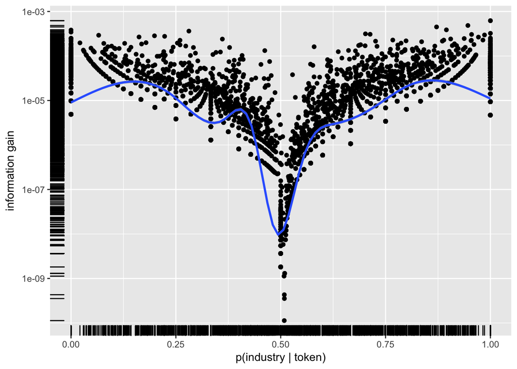

```r
ggplot(info_df, aes(p_industry_token / p_token, delta_H)) +
    geom_point() +
    # geom_hex(bins = 30) +
    geom_rug() +
    geom_smooth() +
    xlab('p(industry | token)') +
    scale_y_log10(name = 'information gain')
```

On this approach, relatively high-scoring terms are relatively frequent in one commenter type and much less frequent in the other.

```r
info_df %>%
    arrange(desc(delta_H)) %>%
    select(token, advocacy, industry, delta_H) %>%
    head(20)
```

```
## # A tibble: 20 × 4
##                   token advocacy industry      delta_H
##                   <chr>    <dbl>    <dbl>        <dbl>
## 1            sugarbeets        0      133 0.0006235239
## 2             sugarbeet        0      132 0.0006188336
## 3                  seed        8      141 0.0004845155
## 4               quality       28      190 0.0004497673
## 5                 sugar       17      145 0.0003867094
## 6              vaccines       78        0 0.0003831110
## 7                     i      353      138 0.0003624793
## 8                  nrdc       70        0 0.0003438080
## 9                   iqa        0       69 0.0003234113
## 10                   no      174      410 0.0003145678
## 11               review      146      363 0.0003074686
## 12         case_control        4       85 0.0003051199
## 13                 beet        1       70 0.0002966336
## 14                   uk       85        6 0.0002925636
## 15                  you      161       40 0.0002840656
## 16                found      181       52 0.0002766153
## 17                toxic      124       24 0.0002675092
## 18 case_control_studies        2       68 0.0002656839
## 19    quality_standards        0       54 0.0002530915
## 20         isoxaflutole       51        0 0.0002504721
```

Simply inspecting this list indicates a few patterns. Agriculture-related terms — sugarbeets, seed, sugar — appear to be strongly associated with industry, while advocacy uses more personal and emotionally weighted language — I, you, my; toxic. Industry also may make more references to formal research standards — IQA, case control studies, quality standards. Vaccines are appear on this list, due to a letter-writing campaign by the organization Moms Across America, based on laboratory test findings of glyphosate contamination in some vaccines.

To proceed, we select approximately 200 focal terms with the highest information gain.

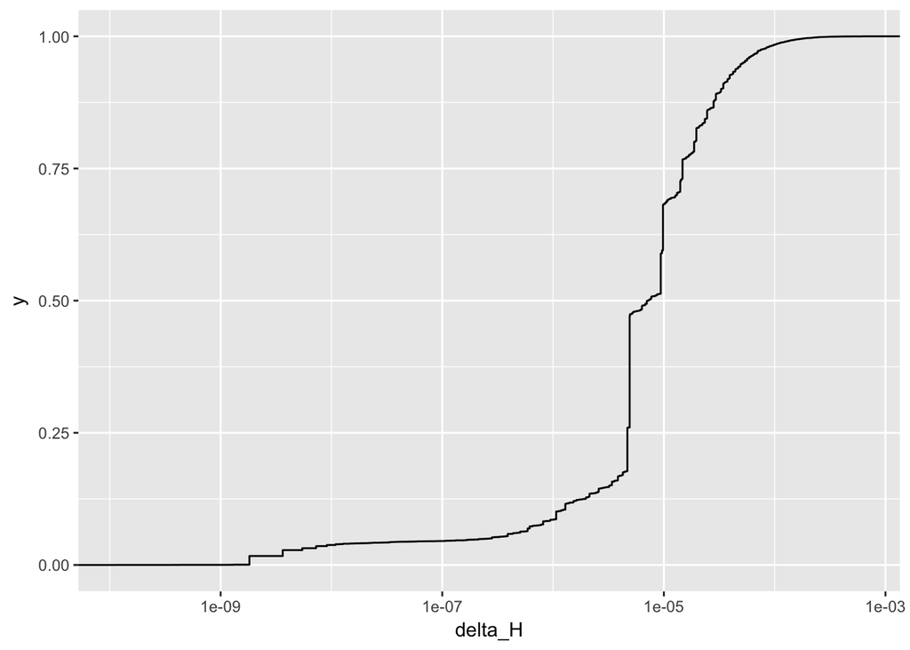

```r
ggplot(info_df, aes(delta_H)) +
    stat_ecdf() +
    scale_x_log10()
```

```r
terms = info_df %>%
    filter(delta_H > 10^-4) %>%
    .$token

matrix(terms, ncol = 2)
```

```
##        [,1]                          [,2]
##   [1,] "acquavella"                  "its"
##   [2,] "acquavella_et"               "key"
##   [3,] "acquavella_et_al"            "levels"
##   [4,] "agrochemical"                "life"
##   [5,] "ahs"                         "link"
##   [6,] "al"                          "mammalian"
##   [7,] "analyses"                    "management"
##   [8,] "attachments"                 "materials"
##   [9,] "attachments_original"        "medical"
##  [10,] "autism"                      "meet"
##  [11,] "ban"                         "milk"
##  [12,] "based_herbicides"            "moa"
##  [13,] "beet"                        "mode"
##  [14,] "beet_sugar"                  "moms"
```

[output cut: 87 more lines]

## Cluster construction

To cluster these terms, we first expand the termlist, identifying the 500 terms closest to the focal terms.

```r
## Load the fitted word2vec model
model = quietly(read.binary.vectors)(w2v_model_file)$result
## Submodel of focal terms
focal_model = model[[terms, average = FALSE]]
## Cosine similarity to the focal terms
focal_sim = cosineSimilarity(model, focal_model)
## Select the 500 terms closest to any of the focal terms
model_trimmed = focal_sim[rank(-apply(focal_sim,1,max)) < 500,]
```

We cluster these 500 terms using cosine similarity and affinity propagation.

```r
## Cosine similarity on the submodel
cos_sim = cosineSimilarity(model_trimmed, model_trimmed)
## Affinity propagation
clusters = aggExCluster(cos_sim, includeSim = TRUE)
```

The dendrogram below shows that the tokens can be arranged into a cluster hierarchy with clear and distinct clusters.

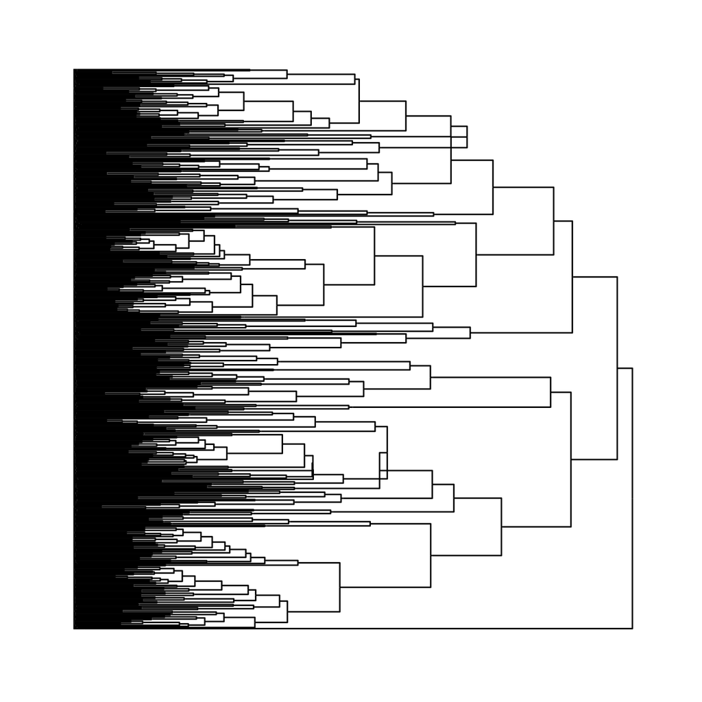

```r
library(ggraph)
clusters %>%
    as.dendrogram() %>%
    ggraph(layout = 'dendrogram', circular = FALSE) +
    geom_edge_elbow() +
    theme_graph() +
    coord_flip()
```

Extracting clusters requires choosing a level at which to cut the dendrogram. Below, we plot the size of the largest cluster against the cut level $h$.

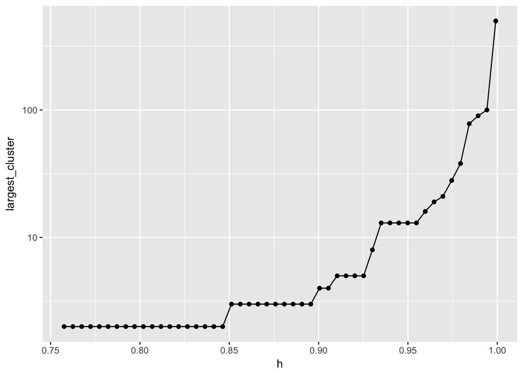

```r
largest_cluster = function (ap_tree, h) {
    clusters %>%
        cutree(h = h) %>%
        sort(decreasing = TRUE, sortBy = 'size') %>%
        .@clusters %>%
        .[[1]] %>%
        length
}
largest_cluster = Vectorize(largest_cluster,
                            vectorize.args = 'h')
tibble(h = seq(min(clusters@height), max(clusters@height),
               length.out = 50),
       largest_cluster = largest_cluster(clusters, h)) %>%
    ggplot(aes(h, largest_cluster)) +
    geom_point() +
    geom_line() +
    scale_y_log10()
```

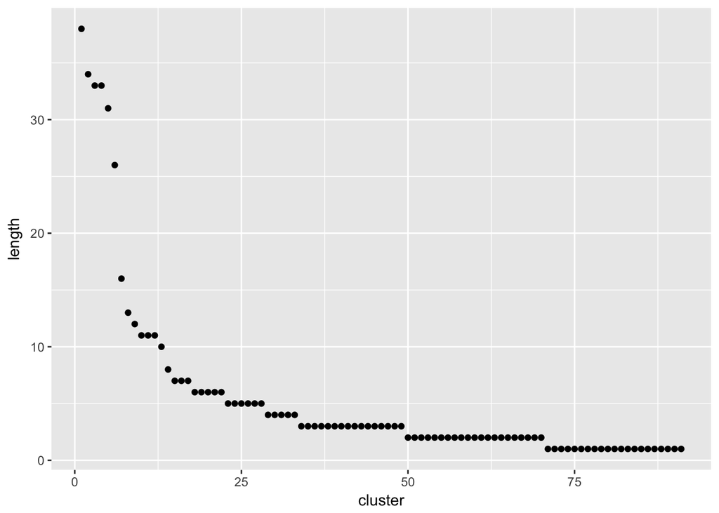

```r
cluster_terms = cutree(clusters, h = .98) %>%
    sort(decreasing = TRUE, sortBy = 'size') %>%
    .@clusters %>%
    map(names)
cluster_terms %>%
    map(length) %>%
    unlist %>%
    tibble(cluster = 1:length(.), length = .) %>%
    ggplot(aes(cluster, length)) + geom_point()
```

```r
nontrivial_clusters = cluster_terms %>%
    map(length) %>%
    unlist %>%
    {. > 5} %>%
    which()
cluster_terms[nontrivial_clusters] -> cluster_terms

cluster_terms
```

```
## [[1]]
##  [1] "810"
##  [2] "p_poly3"
##  [3] "0.02"
##  [4] "cd_1"
##  [5] "cd_1_combined"
##  [6] "0.008"
##  [7] "0.062"
##  [8] "0.063"
##  [9] "p_value"
## [10] "p_0.059"
## [11] "kidney_tumor_incidence"
## [12] "decreasing"
## [13] "trend"
## [14] "1993_atkinson_study"
```

[output cut: 213 more lines]

## Cluster mapping: Vector projection approach

With the clusters defined, we next “map” the clusters on to the individual comments, allowing us to evaluate the presence or extent of each cluster across the comments. This script explores two approaches to cluster mapping. In this section, we construct vector representations of each cluster and comment — in the same vector space as the word embeddings for individual terms — by taking the average of the word vectors in each. We then project the comment vectors into the cluster vectors. The magnitude of the resulting vector gives us an abstract, quantitative representation of the extend to which the cluster is present in the given comment.

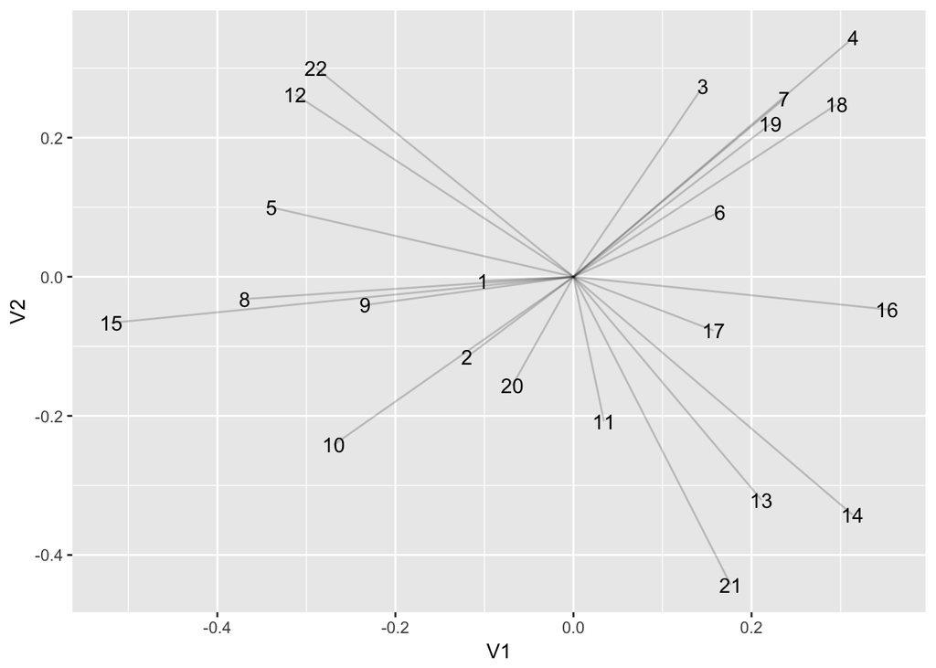

```r
## Build cluster vectors
cluster_vectors = cluster_terms %>%
    map(~ model[[.x]]) #%>%
    # map(normalize_lengths)  # `project` already handles normalization

## MDS projection of cluster vectors
cluster_vectors %>%
    map(normalize_lengths) %>%
    # map(as.matrix) %>%
    reduce(rbind) %>%
    {.%*%t(.)} %>%
    {1-.} %>%
    cmdscale() %>%
    as_tibble() %>%
    mutate(cluster = 1:nrow(.)) %>%
    ggplot() +
    geom_text(aes(V1, V2, label = cluster)) +
    geom_segment(aes(0, 0, xend = V1, yend = V2), alpha = .2)
```

```r
## Build comment vectors
comment_vectors = tokens_df %>%
    split(.$comment_id) %>%
     # .[1:3] %>%
    map(~ .x$token) %>%
    map(~ model[[.x]]) %>%
    reduce(rbind) %>%
    as.VectorSpaceModel()
```

The magnitudes of the projections are not intrinsically meaningful. To interpret them, we convert them into z-scores across all comments. Thus, if the projection of comment $i$ onto cluster $j$ has magnitude 1, $i$ has one standard deviation more association with $j$ than the mean comment.

```r
## Project comments vectors into clusters
comment_z = map(cluster_vectors,
                ~ project(comment_vectors, .x)) %>%
    map(magnitudes) %>%
    ## Arrange into a matrix
    reduce(cbind) %>%
    as_data_frame() %>%
    `colnames<-`(str_c('cluster_', 1:ncol(.))) %>%
    ## Convert to z-score
    mutate_all(funs((. - mean(.))/sd(.))) %>%
    mutate(comment_id = {tokens_df %>%
            split(.$comment_id) %>%
            names}) %>%
    ## Place in long format and rejoin with comments
    gather(cluster, magnitude, starts_with('cluster'),
           factor_key = TRUE) %>%
    inner_join(comments)
```

We then generate dotplots for each cluster.

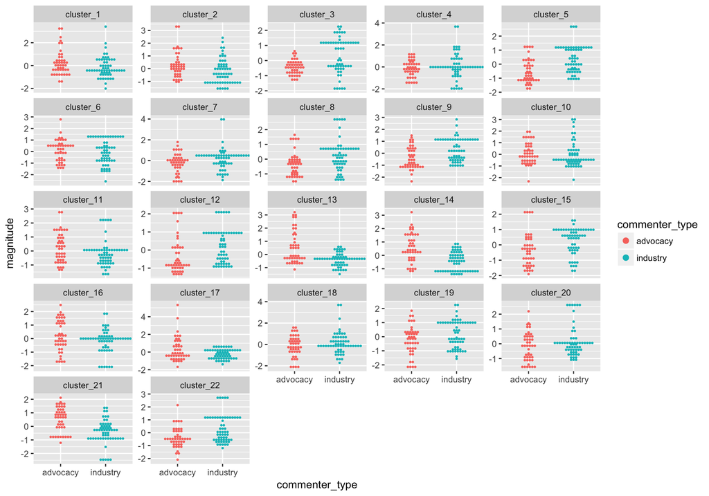

```r
ggplot(comment_z, aes(commenter_type, magnitude,
               fill = commenter_type)) +
    # geom_violin(scale = 'count') +
    geom_dotplot(binaxis = 'y', stackdir = 'center',
                 color = NA, dotsize = 1.2) +
    facet_wrap(~ cluster, scales = 'free_y')
```

```r
cluster_terms[[14]]
```

```
## [1] "hypertension" "bowel"        "throat"       "infertility"
## [5] "auto_immune"  "disorder"     "obesity"      "diabetes"
```

## Cluster mapping: Count approach

This section takes an alternative approach to cluster mapping. Rather than constructing vector embeddings, we simply count occurrences of the terms in a given cluster.

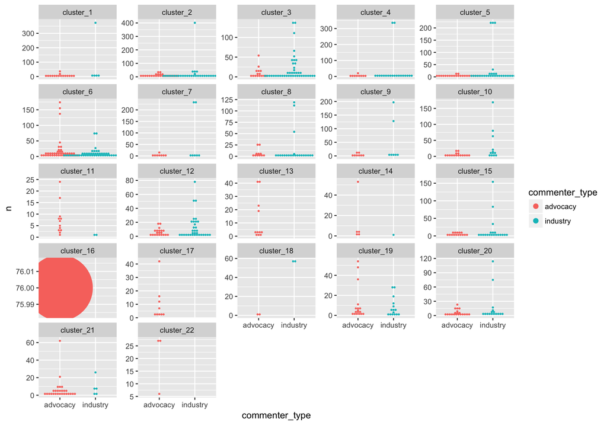

```r
## Count cluster occurrences in comments
comment_counts = cluster_terms %>%
    ## There are a few ways to do this. One is to filter down terms,
    ## then count rows.
    # map(~ {tokens_df %>%
    #       filter(token %in% .x) %>%
    #       group_by(comment_id) %>%
    #       summarize(n = n())}) %>%
    # bind_rows(.id = 'cluster') %>%
    # filter(!duplicated(.)) %>%
    # mutate(cluster = {str_c('cluster_', cluster) %>%
    #                   forcats::as_factor()}) %>%
    ## Here's an approach using an inner join
    tibble(token = .,
           cluster = {str_c('cluster_', 1:length(.)) %>%
            forcats::as_factor()}) %>%
    unnest(token) %>%
    inner_join(tokens_df) %>%
    group_by(comment_id, cluster) %>%
    summarize(n = n()) %>%
    ungroup() %>%
    ## Then join back to the comments
    inner_join(comments)
ggplot(comment_counts, aes(commenter_type, n,
               fill = commenter_type)) +
    geom_dotplot(binaxis = 'y', stackdir = 'center',
                 color = NA, dotsize = 1.2) +
    facet_wrap(~ cluster, scales = 'free_y')
```

```r
cluster_terms[[5]]
```

```
##  [1] "peer_review"
##  [2] "quality_standards"
##  [3] "second_highly_influential"
##  [4] "subset"
##  [5] "meets"
##  [6] "influential_scientific_information"
##  [7] "cancer_assessment"
##  [8] "hisa"
##  [9] "federal_government_quality_standards"
## [10] "sap's_review"
## [11] "must_meet"
## [12] "information"
## [13] "higher_degree"
## [14] "influential_information"
## [15] "reproducibility"
```

[output cut: 16 more lines]

```r
cluster_terms[[6]]
```

```
##  [1] "we"                 "our"                "ourselves"
##  [4] "courage"            "hope"               "listening"
##  [7] "if_you"             "think"              "someone"
## [10] "vote"               "paying"             "you"
## [13] "your"               "now"                "our_food"
## [16] "feed_crops"         "stop"               "do_your_job"
## [19] "please_stop"        "poisoning_our"      "stuff"
## [22] "hurting"            "toxic_chemicals"    "stop_poisoning"
## [25] "our_children"       "future_generations"
```

## Cluster mapping analysis

The vector projection method is more inclusive, in the sense that comments that are semantically “close to” the cluster but do not necessarily contain the cluster terms can still get a relatively high z-score. However, this also makes the vector projection method susceptible to overestimation.

We can also compare the estimates of the two methods. Note that vector projections generate a score for every comment; whereas the count method does not include comments with zero-counts. In the following, we do not include the comments with zero-counts for any given cluster.

```r
scores_combined = inner_join(comment_z, comment_counts)
```

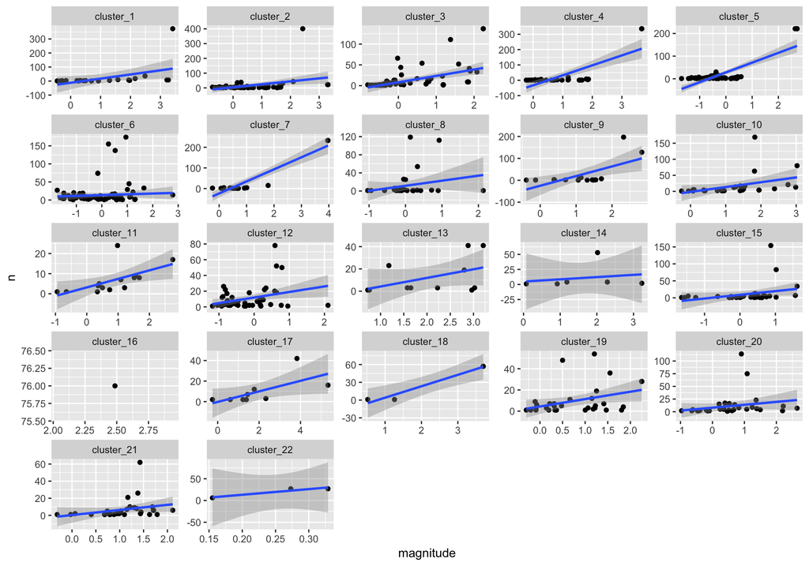

```r
ggplot(scores_combined, aes(magnitude, n)) +
    geom_point() +
    geom_smooth(method = 'lm') +
    facet_wrap(~ cluster, scales = 'free')
```

Taking all clusters together, the correlation is moderate to low.

```r
with(scores_combined, cor(magnitude, n)**2)
```

```
## [1] 0.1492246
```

Taking clusters separately, correlation ranges from effectively 0 to very strong. Note that correlation does not seem to correspond to cluster size (clusters are numbered in descending order by number of terms). However, several of the clusters with high correlations have large outliers in terms of both count and magnitude.

```r
scores_combined %>%
    split(.$cluster) %>%
    map(~ cor(.x$magnitude, .x$n)**2) %>%
    unlist() %>%
    sort(decreasing = TRUE)
```

```
##  cluster_18  cluster_22   cluster_7   cluster_5   cluster_4  cluster_17
## 0.966752232 0.900273238 0.883533379 0.623693658 0.585748055 0.439270885
##   cluster_9  cluster_11  cluster_13   cluster_3   cluster_1  cluster_10
## 0.430133626 0.369645969 0.212156943 0.211852485 0.207997402 0.154572230
##  cluster_19   cluster_2  cluster_12  cluster_15  cluster_21  cluster_20
## 0.133685393 0.123162039 0.106689362 0.088429286 0.078489647 0.050344677
##   cluster_8  cluster_14   cluster_6
## 0.047879038 0.040026381 0.005226991
```